# Mini-Porject Statistique

QIAN Zifei

Mon Oct 26 00:51:52 2015

```r
set.seed(42,kind="Marsaglia-Multicarry")
```

Je vous prie par avance de m’excuser si je commets des erreurs en français. :P

## Exercise 1

### 1.1

Le bias de $T(X)$ en tant qu’estimateur de $g(\theta)$ est $\begin{eqnarray*} bias(\theta,T(X)) &=& \mathbb{E}_{\theta}(T(X)) - g(\theta) \\\\ &=& \frac{1}{n} \sum_{i=1}^n \mathbb{E}_{\theta}(X_i) - g(\theta) \\\\ &=& \frac{1}{n}\times n\times g(\theta) - g(\theta) \\\\ &=& 0 \end{eqnarray*}$ de sorte que $T(X)$ est un estimateur non biasié de $g(\theta)$

La densité de loi $P_\theta$ est $\begin{eqnarray*} p_\theta(x) &=& \frac{d\mathbb{P}(X_1 \leq x)}{dx} \\\\ &=& \frac{d(1-\mathbb{P}(X_1 > x))}{dx} \\\\ &=& \begin{cases} \theta e^{-\theta x}& (x \geq 0) \\\\ 0& (x < 0) \end{cases} \end{eqnarray*}$  
Pour calculer la variance de $T(X)$ et l’information de Fisher $I(g(\theta))$, on va d’abord calculer la variance de X: $\begin{eqnarray*} \mathbb{V}ar(X) &=& \mathbb{E}(X^2) - \mathbb{E}(X)^2 \\\\ &=& \int_0^{\infty} x^2 \theta e^{-\theta x}dx - \frac{1}{\theta ^2} \end{eqnarray*}$ où par l’intégration par parties on peux calculer $\begin{eqnarray*} \int_0^{\infty} x^2\times \theta e^{-\theta x}dx &=& -\int_0^{\infty} x^2de^{-\theta x} \\\\ &=& -\left[x^2e^{-\theta x}\right]_0^{\infty} + \int_0^{\infty}2xe^{-\theta x}dx \\\\ &=& -\frac{1}{\theta}\int_0^{\infty}2xde^{-\theta x} \\\\ &=& -\frac{1}{\theta} \left[2xe^{-\theta x}\right]_0^{\infty} + \frac{2}{\theta}\int_0^{\infty}e^{-\theta x}dx \\\\ &=& -\frac{2}{\theta ^2}\left[e^{-\theta x}\right]_0^{\infty} \\\\ &=& \frac{2}{\theta ^2} \end{eqnarray*}$ Donc, la variance d’X est $\mathbb{V}ar(X) = \frac{2}{\theta ^2} - \frac{1}{\theta ^2} = \frac{1}{\theta ^2}$ La variance de $T(X)$ est ${V}ar_{\theta}(T(X)) = \frac{1}{n^2}\times \sum_{i=1}^n \mathbb{V}ar_{\theta}(X_i) = \frac {1}{n\theta ^2}$ L’information de Fisher est $\begin{eqnarray*} I(\theta) &=& nI_1(\theta) = n*\mathbb{V}ar[\frac{\partial \log p(x,\theta)}{\partial \theta}] \\\\ &=& n*\mathbb{V}ar[\frac{\partial (\log \theta - \theta x)}{\partial \theta}] \\\\ &=& n*\mathbb{V}ar[\frac{1}{\theta} - x]\\\\ &=& n*\mathbb{V}ar[x] = \frac{n}{\theta ^2} \end{eqnarray*}$ D’où, on a $\frac{g'(\theta)^2}{I(\theta)} = \frac{1/\theta ^4}{n/\theta ^2} = \frac{1}{n\theta ^2}$ On peut conclure: l’estimateur $T(X)$ de $g(\theta)$ est non biaisé et vérifie: $\forall \theta > 0, \mathbb{V}ar_{\theta}(T(X)) = \frac{g'(\theta)}{I(\theta)}$ Donc T(X) atteint la borne de Cramér-Rao, c’est-à-dire T(X) est un estimateur UVMB.

### 1.2

Pour l’estimateur $S_\alpha(X)$, le biais est $\begin{eqnarray*} biais(\theta,S_\alpha) &=& \mathbb{E}(\frac{\alpha}{n} \sum_{i=0}^n X_i) - \frac{1}{\theta} \\\\ &=& \frac{\alpha}{n}\sum_{i=0}^n\mathbb{E}(X_i) - \frac{1}{\theta} = \frac{\alpha -1}{\theta} \end{eqnarray*}$ La variance est $\mathbb{V}ar_{\theta}(S_\alpha) = \alpha ^2\mathbb{V}ar(T) = \frac{\alpha ^2}{n\theta ^2}$ Donc, on a $R(\theta, S_\alpha) = biais^2(\theta,S_\alpha) + \mathbb{V}ar_{g(\theta)}(S_\alpha) = \frac{\alpha ^2}{n\theta ^2} + \frac{(\alpha -1)^2}{\theta ^2}$ $R(\theta, T) = \mathbb{V}ar_{\theta}(T) = \frac{1}{n\theta ^2}$ Pour $\forall \theta > 0, R(\theta, S_\alpha ) < R(\theta, T)$ On a $\frac {\alpha ^2}{n\theta ^2} + \frac{(\alpha -1)^2}{\theta ^2} < \frac {1}{n\theta^2}$ $\rightarrow n(1-\alpha)^2 < 1-\alpha ^2$ Si $1-\alpha > 0$, on a $n(1-\alpha) < 1+\alpha$ $\Rightarrow \alpha > \frac{n-1}{n+1}$ Si $1-\alpha < 0$, on a $n(1-\alpha) > 1+\alpha$ $\Rightarrow \alpha < \frac{n-1}{n+1} < 1$ Donc, pour $\alpha \in \big ]\frac{n-1}{n+1},1\big [$, on a $\forall \theta > 0, R(\theta, S_\alpha ) < R(\theta, T)$

### 1.3

D’après Q2, on a $R(\theta, S_\alpha) = \frac{\alpha ^2}{n\theta ^2} + \frac{(\alpha-1)^2}{\theta ^2}$ La dérivée est $R'(\theta, S_\alpha) = \frac{2\alpha}{n\theta ^2} + \frac{2(\alpha -1)}{\theta ^2}$ Puisque $\forall \alpha > 0, R''(\theta, S_\alpha) = \frac{2(n+1)}{n\theta ^2} > 0$. On a $R'(\theta, S_\alpha ^*) = 0$. $\frac{2\alpha}{n\theta ^2} + \frac{2(\alpha -1)}{\theta ^2} = 0$ $\Rightarrow \alpha ^* = \frac{n}{n+1}$

### 1.4

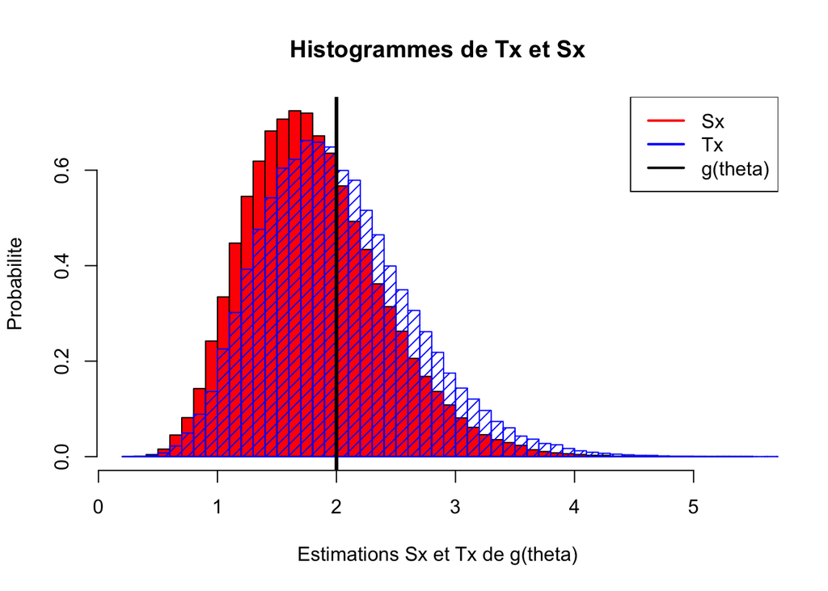

```r
# Definition of Parameters
theta <- 0.5
theta_0 <- 0.5
M <- 100000
n <- 10
alpha <- 10/11 # alpha = n/n+1

#(a)
v = rexp(M*n,theta)
Z = matrix(v, nrow = 10)

#(b)
Tx <- apply(Z, 2, mean)
Sx <- alpha * apply(Z, 2, mean)

# (c)
hist(Sx, col = "red", probability = TRUE,
     main = "Histogrammes de Tx et Sx",
     breaks = 50,
     xlab = "Estimations Sx et Tx de g(theta)",
     ylab = "Probabilite")

hist(Tx, col = "blue", probability = TRUE, add = TRUE, density = 15, breaks = 50)

abline(v = 1/theta_0, lwd = 3)

legend("topright", lwd = 2, col = c("red", "blue", "black"), legend = c("Sx", "Tx", "g(theta)"))
```

```r
mean(Sx)
```

```
## [1] 1.816088
```

```r
mean(Tx)
```

```
## [1] 1.997697
```

```r
#(d)
L_1 <- (Tx-1/theta)^2
L_alpha <- (Sx-1/theta)^2

#(e)
#theoretic value
R_t <- 1/(n*theta^2)
R_s <- alpha^2/(n*theta^2) + (alpha-1)^2/theta^2
#approximation
R_t0 <- mean(L_1)
R_s0 <- mean(L_alpha)
R_t
```

```
## [1] 0.4
```

```r
R_s
```

```
## [1] 0.3636364
```

```r
R_t0
```

```
## [1] 0.3973851
```

```r
R_s0
```

```
## [1] 0.3622368
```

Avec $\frac{10}{11}$ la valeur de alpha, qui est inclus dans $\left[\frac{n-1}{n+1},1\right]$, on a $R_s < R_t$. Cela, même pour les estimations, est conformé à la conclusion de la quesiton 2.

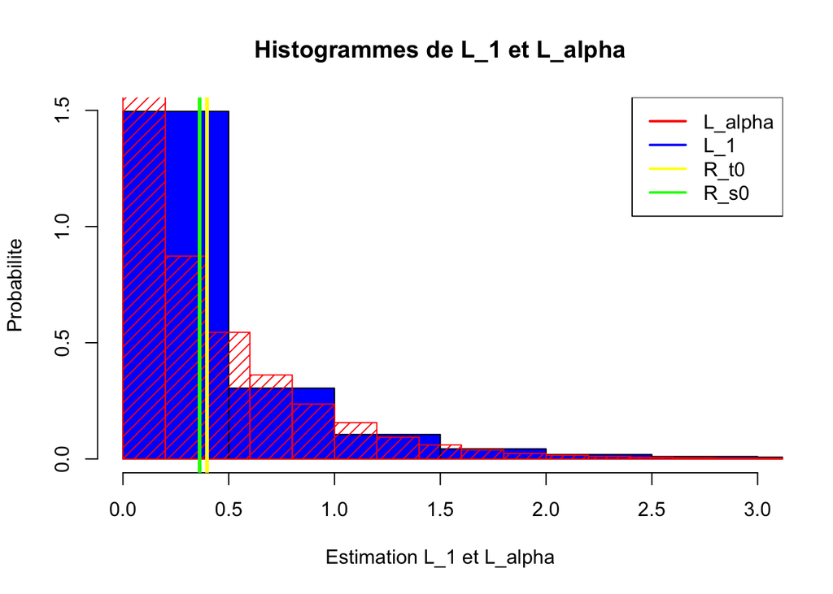

```r
#(f)
hist(L_1, col = "blue", probability = TRUE,
     main = "Histogrammes de L_1 et L_alpha",
     breaks = 50,
     xlim = range(0:3),
     xlab = "Estimation L_1 et L_alpha",
     ylab = "Probabilite")
hist(L_alpha, col = "red", probability = TRUE, add = TRUE, density = 15, breaks = 50)
abline(v = R_t0, lwd = 3, col = "yellow")
abline(v = R_s0, lwd = 3, col = "green")
legend("topright", lwd = 2, col = c("red", "blue", "yellow", "green"), legend=c("L_alpha", "L_1", "R_t0", "R_s0"))
```

## Exercise 2

### **2.1**

Le modèle $\mathcal{P} = \{P_\theta, \theta \in \Theta\}$ est dominé par la mesure de comptage sur $\mathbb{N}$

### 2.2

Notons que $S(y) = \sum_{i=0}^n y_i$, on a, pour $y \in \mathbb{N}^n$ et $\theta > 0$ $\begin{eqnarray*} \pi (\theta | y) &=& \frac {\prod_{i=0}^np_\theta (y_i) \pi(\theta)}{\int_\Theta \prod_{i=0}^np_t(y_i)\pi(dt)} \\\\ &=& \frac{\frac{\theta ^{S(y)}}{\prod_{i=0}^n y!}e^{-n\theta}\frac{\beta ^ \alpha}{\Gamma(\alpha)} \theta ^ {\alpha-1}e^{-\beta \theta} }{\int_0^\infty \frac{\beta ^ \alpha}{\Gamma (\alpha)} t^{\alpha -1} e^{-\beta t}* \frac{t^{S(y)}}{\prod_{i=0}^n y!}e^{-nt}dt}\\\\ &=& \frac{\theta ^ {\alpha + S(y) - 1}e^{-(\beta+n)\theta}}{\int_0^\infty t^{\alpha+S(y)-1}e^{-(\beta+n)t}dt} \\\\ &=& \frac {(\beta+n)^{\alpha + S(y)}}{\Gamma(\alpha+S(y))}\theta^{\alpha+S(y)-1}e^{-(\beta+n)\theta} \end{eqnarray*}$ Donc, la loi a posterior $\pi(\theta |y)$ est $\mathcal{G}amma(\alpha+S(y),\beta+n)$

### 2.3

D’après l’espérance de la loi Gamma, on a $\mathbb{E}(\theta|y) = \frac{\alpha+S(y)}{\beta+n}$ Quand la valeur de n est assez grand, $S(y) \gg \alpha, n \gg \beta$, on a $\mathbb{E}(\theta|y) \approx \frac{S(y)}{n}$ Donc $T(Y) = \mathbb{E}(\theta|y)$ peut être consideré comme un estimateur de $\theta _0$

### 2.4

D’après q3 et la loi des grands nombres, on a $T_n = \mathbb{E}(\theta|Y^n) \overset{n\rightarrow \infty}\longrightarrow \frac{1}{n}\sum_{i=0}^nY_i \overset{n\rightarrow \infty}\longrightarrow \mathbb{E}(Y_1) = \theta _0$ C’est-à-dire, la suite de variables aléatoires $T_n$ converge $\mathbb{P}_{\theta 0}-presque$ sûrement vers $\theta _0$.

### 2.5

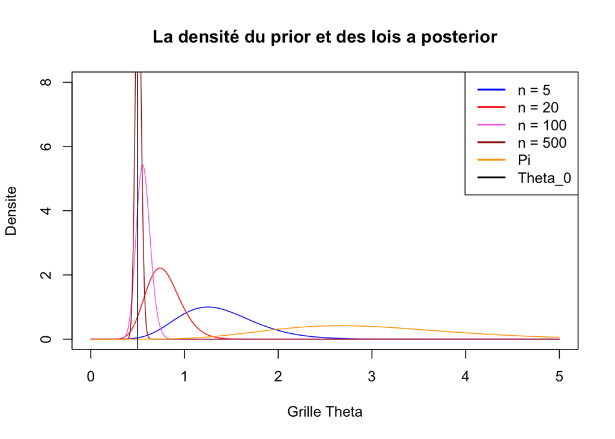

```r
theta_0 <- 0.5
N <- 500
alpha <- 9
beta <- 3

#(a)
Y <- rpois(N, theta_0)
grille <- seq(0, 5, by = 0.01) ## grille of theta

#(b)
den_post_5 <- dgamma(x = grille, shape = alpha+sum(Y[1:5]), rate = beta+5)
den_post_20 <- dgamma(x = grille, shape = alpha+sum(Y[1:20]), rate = beta+20)
den_post_100 <- dgamma(x = grille, shape = alpha+sum(Y[1:100]),rate = beta+100)
den_post_500 <- dgamma(x = grille, shape = alpha+sum(Y[1:500]), rate = beta+500)
den_pi <- dgamma(grille, shape = alpha, rate = beta)

plot(grille,den_post_5, col = "blue", type = "l",
     main = "La densité du prior et des lois a posterior",
     xlab = "Grille Theta", ylab = "Densite",
     ylim = range(0:8))
lines(grille,den_post_20, col = "red")
lines(grille,den_post_100, col = "violet")
lines(grille,den_post_500, col = "brown")
lines(grille, den_pi, col = "orange")
abline(v = theta_0)

legend("topright", lwd = 2, col = c("blue", "red", "violet", "brown", "orange", "black"), legend=c("n = 5", "n = 20", "n = 100", "n = 500", "Pi", "Theta_0"))
```

On peut voir que, plus $n$ est grand, plus l’ésperance s’approche du vrai paramètre theta_0, tandis que la courbe est plus proche de la densité du prior avec un petit $n$.

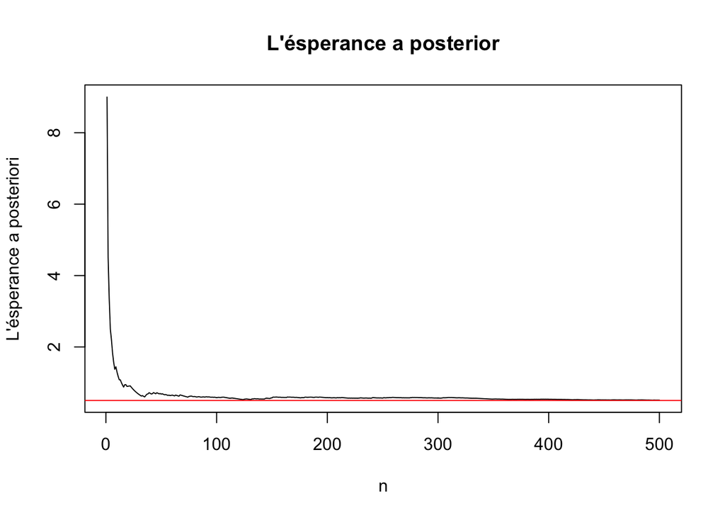

```r
#(c)
E_yn = (alpha+cumsum(Y))/c(1:N)
plot(c(1:N), E_yn, type = "l", main = "L'ésperance a posterior", xlab = "n", ylab = "L'ésperance a posteriori")
abline(h = theta_0, col = "red")
```

On peut voir que, comme $n$ augmente, la courbe de l’ésperance a posterior converge vers le vrai theta_0, 0.5. Cela est conformé à la conclusion de la question 4.

## Exercise 3

### 3.1

Pour une observation $x_1$, le modèle statistique est Bournouille.  
La fonction de densité est $p(x) = \theta^x(1-\theta)^{1-x}$ Les ensembles $\Theta_0 \Theta_1$ sont $\Theta_0 = \{ 0.5 \}$ $\Theta_1 = ]0,1[\backslash \{ 0.5 \}$

### 3.2

La loi de $S(X)$ est la loi binomiale $S(X) \sim B(n,\theta)$ Notons $\theta_0 = 0.5$ le paramètre correspondant à $H_0$. Donc la risque de première espece est $P_{\theta 0}(\{x\in\{0,1 \}^n: \frac{1}{n}S(x) \in [0,1-A] \cup [1-A,1] \}) \leq 5%$ Puisque la loi binomiale de paramètre $\theta_0 = 0.5$ est symétrique autour de $n/2$ Donc, $2P_{\theta 0}(S(x)\in\{0,...,n\}:S(x)\in [0,n(1-A)]) \leq 5%$ D’après la précision du quantile, on a $n(1-A) \leq F^\leftarrow(2.5\%)$ $A \geq 1-\frac{F^\leftarrow(2.5\%)}{n}$

### 3.3

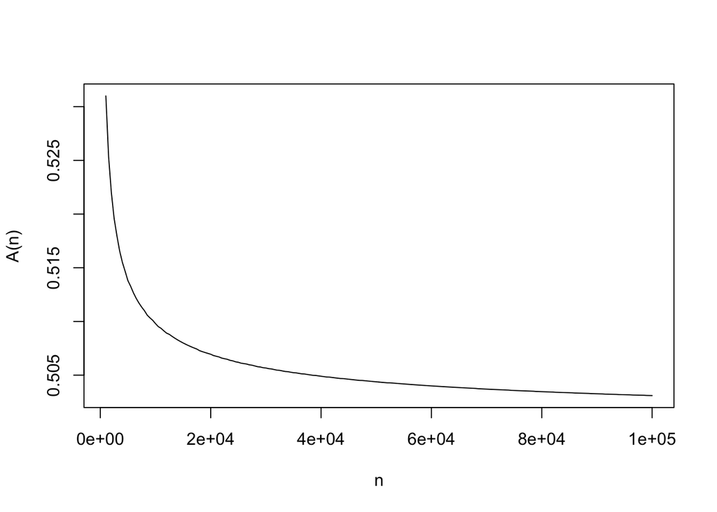

```r
#parameters
theta_0 <- 0.5
alpha <- 5/100
grille <- seq(10^3,10^5, by = 500)
An <- 1-qbinom(alpha/2, grille, theta_0)/grille
plot(grille, An, type = "l", xlab = "n", ylab = "A(n)")
```

### 3.4

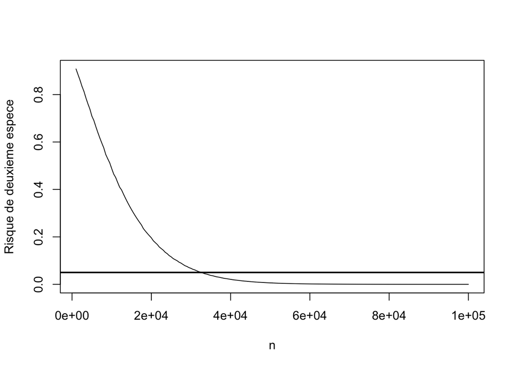

```r
theta <- 0.51
R2n <- pbinom(An*grille, grille, theta)-pbinom((1-An)*grille, grille, theta)
plot(grille, R2n, type = "l",
     xlab = "n",  ylab = "Risque de deuxieme espece")
abline(h = 0.05, lwd = 2)
```

```r
R2n
```

```
##   [1] 9.079328e-01 8.842563e-01 8.611911e-01 8.348643e-01 8.133963e-01
##   [6] 7.856820e-01 7.609787e-01 7.387685e-01 7.089813e-01 6.907950e-01
##  [11] 6.647263e-01 6.402776e-01 6.173040e-01 5.956735e-01 5.752673e-01
##  [16] 5.473899e-01 5.293280e-01 5.122061e-01 4.879656e-01 4.649403e-01
##  [21] 4.506178e-01 4.296268e-01 4.096812e-01 3.976150e-01 3.793788e-01
##  [26] 3.620383e-01 3.455478e-01 3.298637e-01 3.149441e-01 3.007493e-01
##  [31] 2.872415e-01 2.743849e-01 2.621456e-01 2.504916e-01 2.347883e-01
##  [36] 2.243910e-01 2.144871e-01 2.050508e-01 1.960583e-01 1.837500e-01
##  [41] 1.757244e-01 1.680726e-01 1.575062e-01 1.506759e-01 1.441607e-01
##  [46] 1.350901e-01 1.292726e-01 1.211283e-01 1.159333e-01 1.086220e-01
##  [51] 1.039821e-01 9.955170e-02 9.327445e-02 8.931572e-02 8.368050e-02
##  [56] 7.839334e-02 7.508374e-02 7.033813e-02 6.737973e-02 6.312006e-02
##  [61] 6.047495e-02 5.665124e-02 5.306562e-02 5.085306e-02 4.763445e-02
##  [66] 4.461686e-02 4.276574e-02 4.005691e-02 3.751770e-02 3.596859e-02
##  [71] 3.368902e-02 3.155246e-02 3.025573e-02 2.833746e-02 2.653972e-02
```

[output cut: 25 more lines]

$R2n[65]$ est la première valeur qui est plus petit que 0.05 (et donc beta = 1-R > 0.95). Donc, $n_0 = grille[65] = 33000$.

### 3.5

Puisque A(n) est calculé sous la limite de risque de première espèce plus petit que 0.05, il reste de trouver le $n$ dont la risque de deuxième espèce est moins de 0.05. D’après le résultat R2n de Q4, on peux voir que, R2n[64] = 0.0509 > 0.05 alors R2n[65] = 0.047 < 0.05. La courbe de R2n est décoissant, donc $n_0$ demandé est forcément entre grille[64] et grille[65]. Constuisons une grille de les valeurs de n correspondants (grille[64] et grille[65]), avec le pas = 10 sous la limite de la précision de +/-10 Recalculer A(n) et R2n.

```r
grille <- seq(grille[64], grille[65], by = 10)
An <- 1-qbinom(alpha/2, grille, theta_0)/grille
R2n <- pbinom(An*grille, grille, theta)-pbinom((1-An)*grille, grille, theta)
grille
```

```
##  [1] 32500 32510 32520 32530 32540 32550 32560 32570 32580 32590 32600
## [12] 32610 32620 32630 32640 32650 32660 32670 32680 32690 32700 32710
## [23] 32720 32730 32740 32750 32760 32770 32780 32790 32800 32810 32820
## [34] 32830 32840 32850 32860 32870 32880 32890 32900 32910 32920 32930
## [45] 32940 32950 32960 32970 32980 32990 33000
```

```r
R2n
```

```
##  [1] 0.05085306 0.05076347 0.05067403 0.05058474 0.05049560 0.05040660
##  [7] 0.05031776 0.05022906 0.05014051 0.05005211 0.04996385 0.04987574
## [13] 0.04978778 0.04969997 0.04961230 0.04952478 0.04943740 0.04935017
## [19] 0.04926309 0.04917615 0.04908936 0.04900271 0.04891621 0.04882985
## [25] 0.04874363 0.04865756 0.04857164 0.04848585 0.04840021 0.04831472
## [31] 0.04822936 0.04925932 0.04917251 0.04908585 0.04899932 0.04891295
## [37] 0.04882671 0.04874062 0.04865468 0.04856887 0.04848321 0.04839770
## [43] 0.04831232 0.04822709 0.04814200 0.04805706 0.04797225 0.04788759
## [49] 0.04780307 0.04771868 0.04763445
```

Ici, R2n[11] c’est le premier element qui est inférieur à 0.05. Le correspondant grille[11] = 32600. Donc, $n_0$ = 32600.